# Week 10, Notes & Exercises

Statistical Thinking (ETC2420 / ETC5242)

Published

Semester 2, 2025

This week we explore a dataset about Lego sets using multiple linear regression models.

We need the following R packages:

```r
library(tidyverse)
library(openintro)
library(GGally)
library(broom)
library(car)
library(meifly)
```

Make sure that you work through these notes and exercises *linearly*, from start to finish. The later content builds upon earlier stages and assumes you have completed each exercise.

# Lego

Lego is popular system of construction toys consisting of various types of plastic parts, called *bricks*, that can be joined together to make models. The parts are typically sold in *sets* that consist of a set of bricks and instructions for how to put those bricks together to make a particular model. The sets also include plastic figurines, called *minifigures*.

If you are not familiar with Lego, do an online image search for “Lego” to see many examples.

Here are two particular sets that we will look at:  
https://www.lego.com/en-au/product/stephanie-s-soccer-practice-41330  
https://www.lego.com/en-au/product/safari-off-roader-60267

Each Lego set has a unique *item number* and is part of a *theme*. The examples above come from the “Friends” and “City” themes. Today, we will explore some data about sets from these two themes.

## Lego data

The following code chunk will create a tibble called `lego` that will contain the data we will use for today’s exercises.

```r
lego <- lego_sample |>
  filter(theme %in% c("Friends", "City"))
```

These data were collected a few years ago and consist of a sample of Lego sets, recording various features of these sets and also their sale price on Amazon at the time.

Explore this dataset to familiarise yourself with what each variable means and what kind of values are recorded.

For example, you could:

- Read the help page for the original data (`help("lego_sample")`)
- Look directly at the data (`View(lego)`)
- Create any visualisations that you find helpful.

Pay particular attention to the following columns, which we will use today:

- `theme`
- `pieces`
- `amazon_price`
- `year`
- `pages`
- `minifigure`
- `unique_pieces`

The variable `amazon_price` is the sale price on Amazon. We will use this as the response variable in the models we build. Henceforth we will use “sale price” to refer to this particular price (and we will ignore the variable `price`, which is the recommended retail price).

*Exercises 1–4*

1. Do any of the variables above have missing values (`NA`)?  
   If so, can we replace them with a suitable value?

Yes, I think there are several variables missing especially in minifigures , packaging and weight.

```r
lego <- lego |> replace_na(list(minifigures =0))
```

```r
lego_missing <- is.na(lego$ minifigures)
lego[lego_missing,"manufactures"] <-0
```

2. Add a new variable to `lego` called `is_city` that has a value of 1 if the set is from the City theme and a value of 0 otherwise.

   (This type of variable is known as an *indicator variable*. We will use it later as part of building our models.)

```r
library(dplyr)

lego <- lego %>%
  mutate(is_city = if_else(theme == "City", 1, 0))
```

3. Use `ggpairs()` to create a visualisation of the variables listed above.

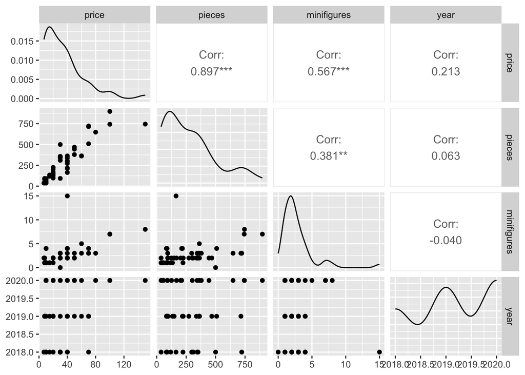

```r
library(dplyr)
library(GGally)

# pick the variables you mentioned (edit the names to match your data)
vars <- c("price", "pieces", "minifigures", "year", "is_city")

lego_plot_data <- lego %>%
  select(any_of(vars)) %>%
  # keep numeric columns for correlations / densities, etc.
  mutate(is_city = as.factor(is_city)) %>%
  tidyr::drop_na()

GGally::ggpairs(
  lego_plot_data,
  columns = c("price", "pieces", "minifigures", "year")
)
```

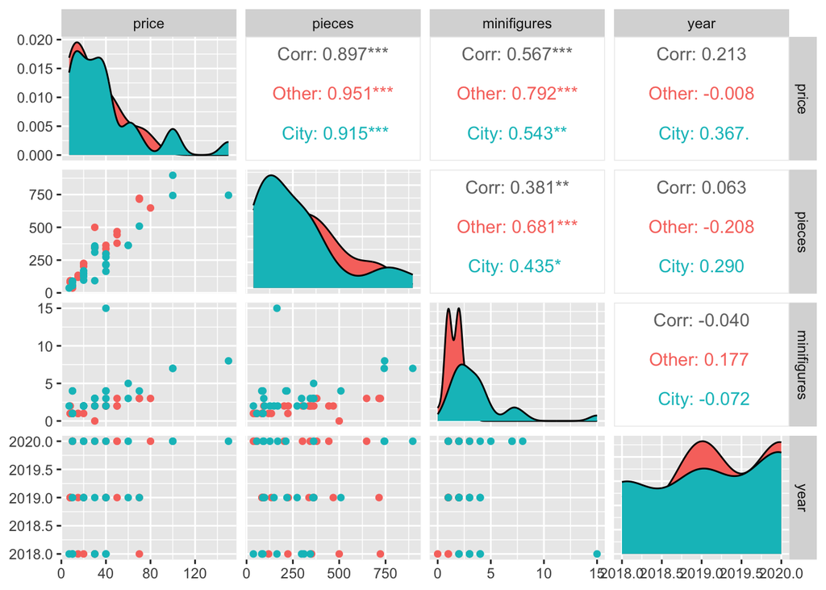

```r
library(dplyr)
library(GGally)

vars <- c("price", "pieces", "minifigures", "year", "is_city")

lego_plot_data <- lego %>%
  select(any_of(vars)) %>%
  mutate(is_city = factor(is_city, levels = c(0, 1), labels = c("Other", "City"))) %>%
  tidyr::drop_na()

GGally::ggpairs(
  lego_plot_data,
  columns = c("price", "pieces", "minifigures", "year"),
  mapping = aes(color = is_city),
  progress = FALSE
)
```

4. Draw a scatter plot of the Amazon price vs the number of pieces in the set. Distinguish the two themes by colour (i.e., plot each point in one of two colours, based on which of the two themes each point represents).

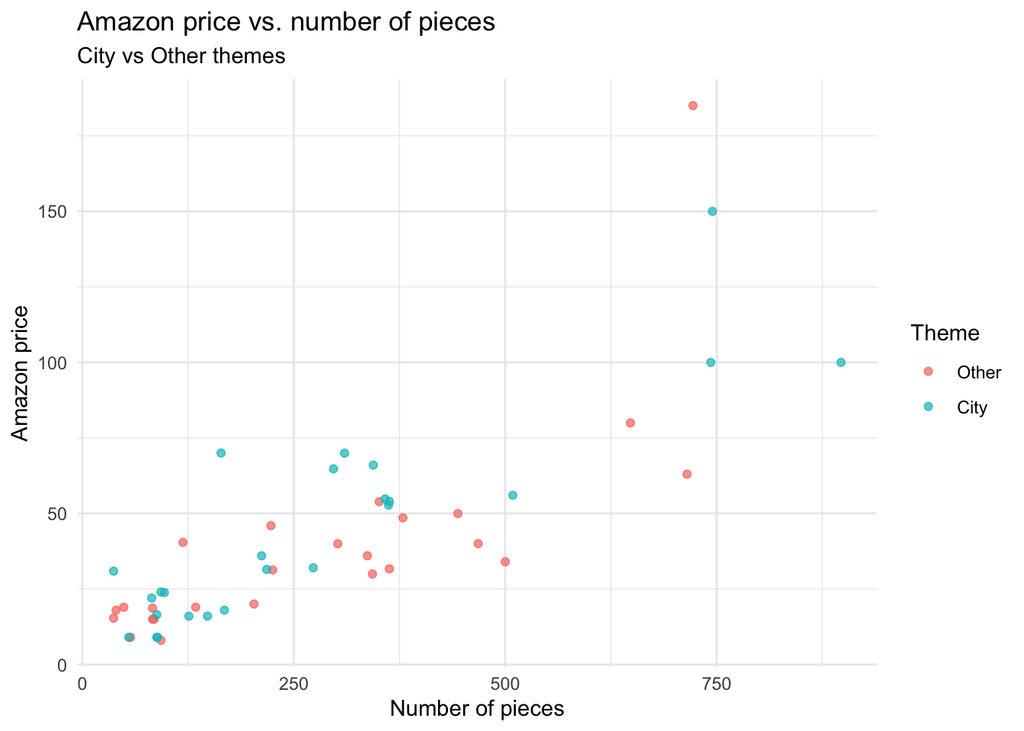

```r
library(dplyr)
library(ggplot2)

# If your price column is named differently (e.g., price_amazon), change it below
lego_plot <- lego %>%
  mutate(
    is_city = factor(is_city, levels = c(0, 1), labels = c("Other", "City"))
  ) %>%
  tidyr::drop_na(amazon_price, pieces)

ggplot(lego_plot, aes(x = pieces, y = amazon_price, color = is_city)) +
  geom_point(alpha = 0.7) +
  labs(
    x = "Number of pieces",
    y = "Amazon price",
    color = "Theme",
    title = "Amazon price vs. number of pieces",
    subtitle = "City vs Other themes"
  ) +
  theme_minimal()
```

## Questions for today

In today’s exercises we explore the following broad questions:

A. Do City sets cost more than Friends sets? (This is a **description** question.)

No, there is not enough evidence to illustrate that the city set cost more than friends set.

B. Can we predict the sale price based on features of each set? (This is a **prediction** question.)

Sure, I think we could use the linear model to predict each set.

```r
# --- Packages ---------------------------------------------------------------
library(dplyr)
library(tidyr)
library(tidymodels)
library(GGally)


lego_city <- lego |> filter (is_city == "1")
lego_other <- lego |> filter (is_city == "0")
# 假设你的目标变量是 sale_price，特征包括 pieces, minifigures, year, is_city
model_lm_1 <- lm(amazon_price ~ pieces + minifigures + year + is_city, data = lego_city)

model_lm_2 <- lm(amazon_price ~ pieces + minifigures + year + is_city, data = lego_other)
# 查看回归结果
summary(model_lm_2)
```

```
Call:
lm(formula = amazon_price ~ pieces + minifigures + year + is_city,
    data = lego_other)

Residuals:
    Min      1Q  Median      3Q     Max
-31.517 -11.584  -1.331   6.202  76.016

Coefficients: (1 not defined because of singularities)
              Estimate Std. Error t value Pr(>|t|)
(Intercept)  2.808e+04  1.360e+04   2.065   0.0515 .
pieces       7.947e-02  3.246e-02   2.448   0.0232 *
minifigures  1.403e+01  8.570e+00   1.637   0.1166
year        -1.391e+01  6.735e+00  -2.065   0.0515 .
is_city             NA         NA      NA       NA
---
Signif. codes:  0 '***' 0.001 '**' 0.01 '*' 0.05 '.' 0.1 ' ' 1

Residual standard error: 22.07 on 21 degrees of freedom
Multiple R-squared:  0.6576,    Adjusted R-squared:  0.6087
F-statistic: 13.44 on 3 and 21 DF,  p-value: 4.068e-05
```

# Simple models

To start with, let’s use the techniques we have learnt earlier (up to and including simple linear regression) to do some relevant analyses.

*Exercises 5–6*

5. What is the average sale price for each theme in the dataset?  
   Which theme costs more, and by how much?

```r
mean(lego_city$price)
```

```
[1] 39.87
```

```r
mean(lego_other$price)
```

```
[1] 29.67
```

6. Use simple linear regression to model how the sale price depends on the number of pieces in the set. Do this separately for the Friends and City sets. Look at the regression coefficients of the fitted models. What do you notice? How does that relate to the result of Exercise 5?

# Multiple regression

## First steps

In a multiple regression model we specify multiple (more than one) predictor variables.

Consider the following model:

```r
model1 <- lm(amazon_price ~ pieces + is_city, data = lego)
```

We can write the model equation for this as follows:
$$y = \beta_0 + \beta_\text{pieces} \, x_\text{pieces} +
\beta_\text{city} \, x_\text{city} + \varepsilon$$

This has two predictor variables:

- The number of pieces in each set (`pieces`, $x_\text{pieces}$)
- An indicator variable to specify whether each set is in the City theme (`is_city`, $x_\text{city}$)

The indicator variable only has two possible values, 0 or 1. That means the value of $\beta_\text{city}$ effectively just gets “added on” to the intercept for Lego sets in the City theme, and doesn’t appear for sets in the Friends theme. In other words, the above equation will simplify to the following:
$$y =
\begin{cases}
(\beta_0 \;\: \phantom{+ \beta_\text{city}}) +
\beta_\text{pieces} \, x_\text{pieces} + \varepsilon & \text{(Friends set)} \\
(\beta_0 + \beta_\text{city}) +
\beta_\text{pieces} \, x_\text{pieces} + \varepsilon & \text{(City set)} \\
\end{cases}$$

This is similar to the simple linear regression models we fitted in the earlier exercises, except that here they are combined together into a single model. Also, here they are constrained to have the same slope parameter, $\beta_\text{pieces}$, rather than allowed to have a different value for the slope for each theme.

*Exercises 7–8*

7. Fit the above model. Show that this model gives a similar fit to the simple linear regression models.
8. What is the interpretation of $\beta_\text{city}$ in this model?

## Full model

Let’s now fit a model that has **all** of our desired predictors:

```r
formula_full <- amazon_price ~ pieces + is_city + year + pages + minifigures + unique_pieces
model_full <- lm(formula_full, data = lego)
tidy(model_full)
```

For convenience later on, we have stored the model formula in its own object (`formula_full`) and simply passed this to the `lm()` function.

*Exercise 9*

9. Explore diagnostic plots for this model. What can you say about the residuals?

*There are further exercises on model checking and diagnostics at the bottom of these notes (see Further diagnostics). Typically we would go through those steps first before proceeding further. However, we have moved those parts to the end to allow you to cover some of the more important material earlier. We recommend working through the exercises in the order we have presented.*

## Interpretation of coefficients

Consider the following models:

```r
tidy(lm(amazon_price ~ is_city,                        data = lego))
tidy(lm(amazon_price ~ is_city + pieces,               data = lego))
tidy(lm(amazon_price ~ is_city          + minifigures, data = lego))
tidy(lm(amazon_price ~ is_city + pieces + minifigures, data = lego))
```

Each model includes the `is_city` predictor. We can try to interpret the coefficient of this predictor as a way to quantify the difference between Friends and City sets.

*Exercises 10–13*

10. Fit the above models and look at the fitted coefficient values. What do you notice?
11. Can you explain why the estimated coefficients of `is_city` are the same/different across these models?

    The following plots might help:

    ```r
    lego |>
      ggplot(aes(x = pieces, y = theme)) +
      geom_boxplot(col = "blue", fill = "lightblue") +
      theme_bw()

    lego |>
      ggplot(aes(x = pieces)) +
      geom_histogram(bins = 15) +
      facet_grid(theme ~ .) +
      theme_bw()

    lego |>
      ggplot(aes(x = minifigures, y = theme)) +
      geom_boxplot(col = "blue", fill = "lightblue") +
      theme_bw()

    lego |>
      ggplot(aes(x = minifigures)) +
      geom_bar() +
      facet_grid(theme ~ .) +
      theme_bw()
    ```

12. For each model, what is the meaning of the coefficient of `is_city` (i.e., how do we interpret it)?
13. Today’s first broad question was, “Do City sets cost more than Friends sets?”  
    Based on the analyses thus far, how would you answer this question?

# Model selection

We have many possible predictors we could use. Which set of them would give the best model, for prediction?

We explore two automated approaches for selected a good set of predictors.

## Stepwise selection

The idea behind *stepwise selection* is to consider adding or removing predictors one at a time to see whether it would improve the model. The best such addition or deletion is selected, and the process is repeated until no such improvements can be found.

To determine which choices improve the model at each step, a model performance measure is used, such as the Akaike information criterion (AIC). The choice that gives the best performance based on this measure is selected.

To start the algorithm, we need to begin with a particular model and also a set of all possible predictors we wish to consider. The full algorithm would allow adding or removing predictors at each step. However, it is possible to restrict the choices to only consider adding new predictors (this is called *forward selection*) or only consider removing existing predictors (this is called *backward elimination*).

The algorithm is not guaranteed to find the best model, and using it with different starting points or directions (forward vs backward) can also lead to different final models. Therefore, in practice it can be helpful to try it with different starting points, and also use it more as an exploratory tool rather than as the final and only method to select a model.

The function `step()` in R will run stepwise selection with a given model. Here’s how we can use it.

Running it with a given model will, by default, run backward elimination with that model:

```r
step1 <- step(model_full)
```

To allow both adding and removing predictors at each step, specify the `direction = "both"` argument:

```r
step2 <- step(model_full, direction = "both")
```

In both of the above, we have started with the full model and let the algorithm select some subset of the predictors. We could instead start with a very simple model and let the algorithm add further predictors. To do so, we need to tell `step()` which predictors it is allowed to use. We do that by specifying a second argument that contains all of the allowed predictors, in the form of a formula (the same as when specifying a model). For example:

```r
model_empty <- lm(amazon_price ~ 1, data = lego)
step3 <- step(model_empty, formula_full)
```

Notice that in this way of using `step()`, it will automatically allow adding and removing predictors, without needing to specify `direction = "both"`.

It might seem more cumbersome to set it up this way compared to the earlier versions. When there are a large number of predictors, it could be difficult or impossible to fit a model with all of them included (a “full” model), in which case the only option for us is to start `step()` with a simpler model.

*Exercise 14*

14. Run stepwise selection in the three ways described above. What models get chosen each time?  
    How do `step1`, `step2` and `step3` relate to each other?

## Exhaustive search

If the number of predictors is relatively small, it is possible to simply try all possible combinations and select the best one. The function `fitall()` from the `meifly` package can do that for us.

Here is how we use it:

```r
lego_predictors <- c("pieces", "is_city", "year", "pages", "minifigures", "unique_pieces")
lego_models <- fitall(lego$amazon_price,
                      lego[, lego_predictors],
                      method = "lm")
```

The object `lego_models` now contains a list of **all** of the fitted models (63 of them in this case!). The best way to see the results is to use `summary()` to get model performance measures for each model, sorted in order by performance and focusing on the top few models:

```r
summary(lego_models) |>
  arrange(desc(AIC)) |>
  head(5)
```

Note: the AIC and BIC values in these summaries are **negated** (i.e., the negative AIC value is reported, rather than AIC itself), which means **larger** values are better.

An alternative summary to the above is to use `glance()` (from the `broom` package) as follows:

```r
lego_models |>
  map_df(glance) |>
  mutate(model = seq_along(lego_models)) |>
  arrange(AIC) |>
  select(logLik, AIC, BIC, r.squared, adj.r.squared, nobs, model) |>
  head(5)
```

```r
model_best <- lego_models[[21]]
```

*Exercise 15*

15. How does model 21 from here compare to the models chosen earlier by stepwise selection?  
    Which model would you recommend should be selected for prediction?

# Further diagnostics

*In a standard modelling scenario, you would explore the following model checks before proceeding to a final model or doing extensive model selection. We have moved these parts here at the end to ensure you cover the more important material earlier. Go through the material above first before tackling this section.*

## Influential points

*Exercises 16–17*

16. Consider the full model. Are there any potentially highly influential points? Calculate the rule-of-thumb threshold for the leverage score and Cook’s $D$ and find all data points that pass this threshold.
17. Investigate these points and comment on anything you notice.

## Collinearity

*Exercise 18*

18. Calculate the variance inflation factor (VIF) for each predictor.

In exploring the data (see Exercise 3) you hopefully noticed that the number of pieces in each Lego set is highly correlated with the number of unique pieces. If we include both of these as predictors in a regression model, we will see the impact of collinearity on the model fit.

Consider the following models:

```r
tidy(lm(amazon_price ~ pieces + unique_pieces, data = lego))
tidy(lm(amazon_price ~ pieces,                 data = lego))
tidy(lm(amazon_price ~          unique_pieces, data = lego))
```

*Exercise 19*

19. How do the standard errors for `pieces` and `unique_pieces` vary across these models?